# Tugas Minggu 5

Ananda Putra Wijaya/G1401221111

2024-09-20

# Inisiasi Library

```r
library(ggplot2)
library(tsibble)
library(tseries)
library(MASS)
library(tseries)
library(readxl)
```

# Inisiasi Data

```r
index=seq(1:100)
index150=seq(1:50)
index51100=seq(from=51,to=100,by=1)
datafull=read.csv("C:/Tugas/Semester 5/Metode Peramalan Deret Waktu/Minggu 5/Data Project Week 5.csv")
data100=ts(datafull[,2])
data150=ts(datafull[1:50,2])
data51100=ts(datafull[51:100,2])
```

# Data Full

## Time Series Plot

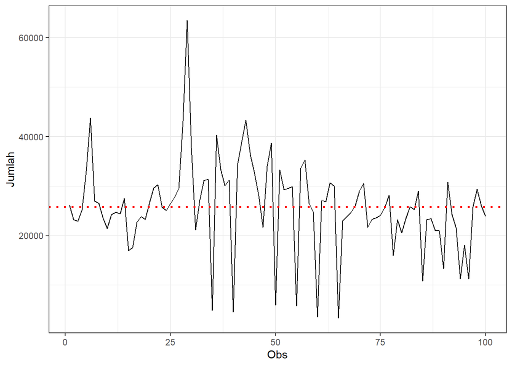

```r
plot_data100 <- data100 |> as_tsibble() |>
  ggplot(aes(x = index, y = value)) + geom_line() + theme_bw() + geom_hline(yintercept = mean(data100), linetype = "dotted", color = "red", size = 1)+
  xlab("Obs") + ylab("Jumlah")
plot_data100
```

```r
mean(data100)
```

```
## [1] 25818.95
```

Plot deret waktu di atas menunjukkan bahwa data penuh tampak **stasioner dalam rataan**, yang ditandai dengan data yang menyebar di sekitar nilai tengah. Namun **tidak stasioner dalam ragam** karena lebar pitanya cenderung tidak sama.

## ACF Plot

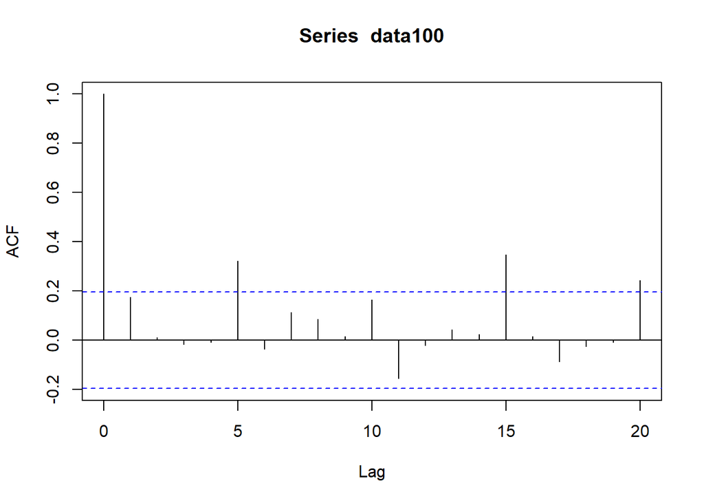

```r
acf(data100)
```

Plot ACF data penuh menunjukkan data penuh cenderung *tails off*

## ADF Test

```r
adf.test(data100)
```

```
##
##  Augmented Dickey-Fuller Test
##
## data:  data100
## Dickey-Fuller = -3.4122, Lag order = 4, p-value = 0.05645
## alternative hypothesis: stationary
```

$H_0$ : Data tidak stasioner dalam rataan

$H_1$ : Data stasioner dalam rataan

Berdasarkan *p-value* dari uji ADF pada data penuh(0.05645), keputusan yang diambil adalah **tak tolak H0**, artinya data **tidak stasioner dalam rataan**.

## Box-Cox Plot

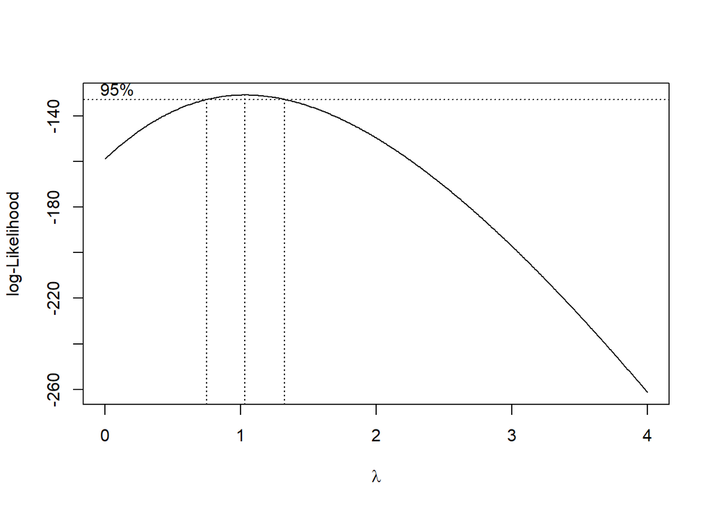

```r
bc100 = boxcox(data100~index, lambda = seq(0,4,by=0.01))
```

```r
#Nilai Rounded Lambda
lambda <- bc100$x[which.max(bc100$y)]
lambda
```

```
## [1] 1.03
```

```r
#SK
bc100$x[bc100$y > max(bc100$y) - 1/2 * qchisq(.95,1)]
```

```
##  [1] 0.76 0.77 0.78 0.79 0.80 0.81 0.82 0.83 0.84 0.85 0.86 0.87 0.88 0.89 0.90
## [16] 0.91 0.92 0.93 0.94 0.95 0.96 0.97 0.98 0.99 1.00 1.01 1.02 1.03 1.04 1.05
## [31] 1.06 1.07 1.08 1.09 1.10 1.11 1.12 1.13 1.14 1.15 1.16 1.17 1.18 1.19 1.20
## [46] 1.21 1.22 1.23 1.24 1.25 1.26 1.27 1.28 1.29 1.30 1.31 1.32
```

Plot *Box-Cox* di atas menunjukkan nilai ($\lambda$) optimum sebesar **1,03** dan pada selang kepercayaan 95% nilai memiliki batas bawah **0,76** dan batas atas **1.32**. Selang tersebut memuat nilai satu sehingga dapat dikatakan bahwa data penuh **stasioner dalam ragam**.

# Data 1 sampai 50

## Time Series Plot

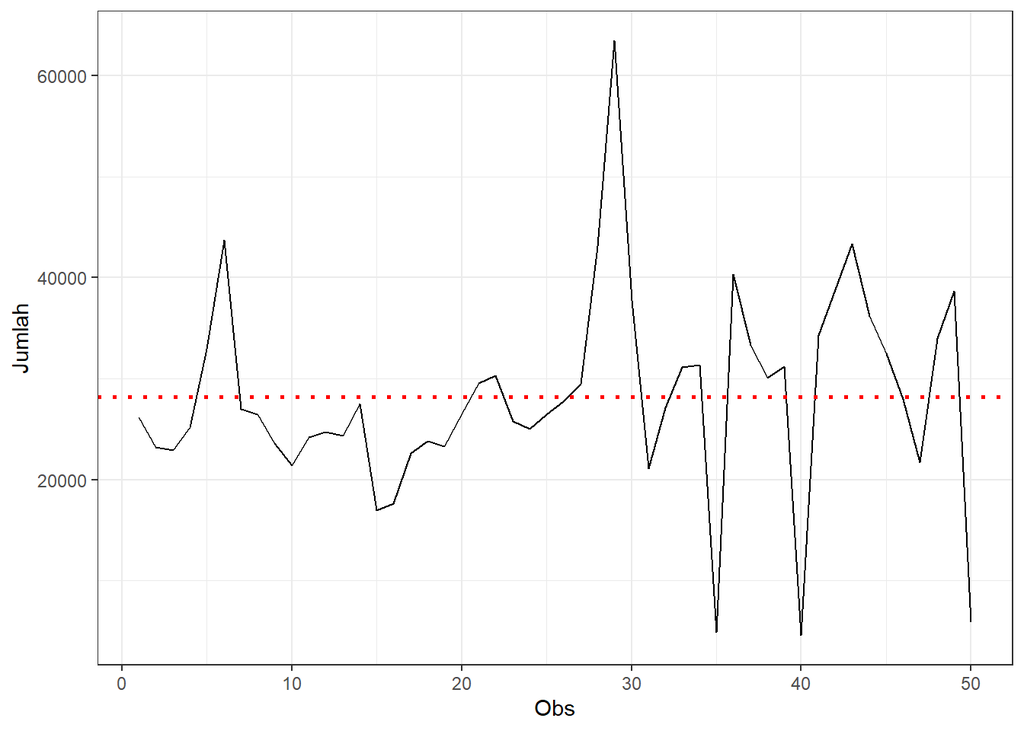

```r
plot_data150 <- data150 |> as_tsibble() |>
  ggplot(aes(x = index, y = value)) + geom_line() + theme_bw() + geom_hline(yintercept = mean(data150), linetype = "dotted", color = "red", size = 1) + xlab("Obs") + ylab("Jumlah")
plot_data150
```

```r
mean(data150)
```

```
## [1] 28227.88
```

Plot deret waktu di atas menunjukkan bahwa data index 1 sampai 50 tampak **stasioner dalam rataan**, yang ditandai dengan data yang menyebar di sekitar nilai tengah. Namun **tidak stasioner dalam ragam** karena lebar pitanya cenderung tidak sama.

## ACF Plot

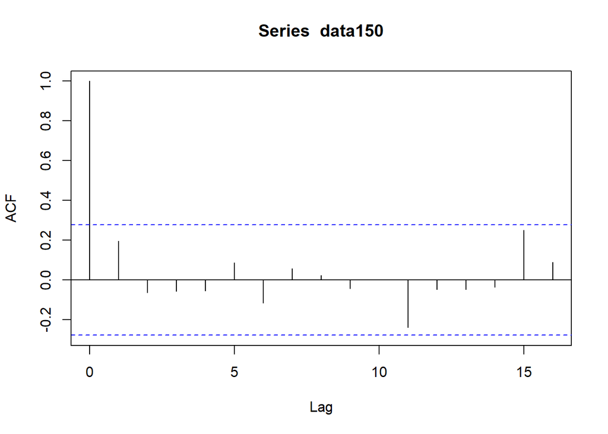

```r
acf(data150)
```

Plot ACF data index 1 sampai 50 menunjukkan data penuh cenderung *tails off*

## ADF Test

```r
adf.test(data150)
```

```
##
##  Augmented Dickey-Fuller Test
##
## data:  data150
## Dickey-Fuller = -3.3008, Lag order = 3, p-value = 0.08159
## alternative hypothesis: stationary
```

$H_0$ : Data tidak stasioner dalam rataan

$H_1$ : Data stasioner dalam rataan

Berdasarkan *p-value* dari uji ADF pada data index 1-50(0.08159), keputusan yang diambil adalah **tak tolak H0**, artinya data **tidak stasioner dalam rataan**.

## Box-Cox Plot

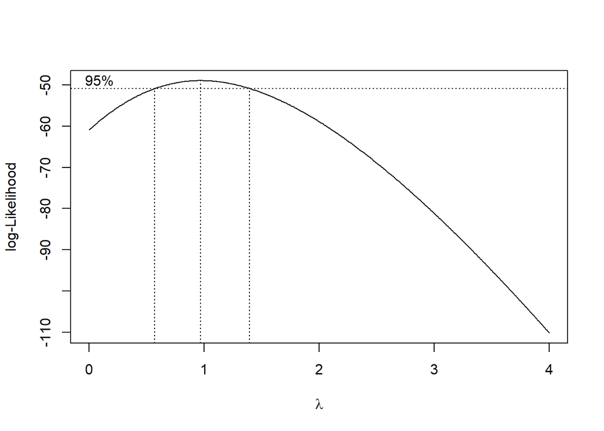

```r
bc150 = boxcox(data150~index150, lambda = seq(0,4,by=0.01))
```

```r
#Nilai Rounded Lambda
lambda <- bc150$x[which.max(bc150$y)]
lambda
```

```
## [1] 0.97
```

```r
#SK
bc150$x[bc150$y > max(bc150$y) - 1/2 * qchisq(.95,1)]
```

```
##  [1] 0.57 0.58 0.59 0.60 0.61 0.62 0.63 0.64 0.65 0.66 0.67 0.68 0.69 0.70 0.71
## [16] 0.72 0.73 0.74 0.75 0.76 0.77 0.78 0.79 0.80 0.81 0.82 0.83 0.84 0.85 0.86
## [31] 0.87 0.88 0.89 0.90 0.91 0.92 0.93 0.94 0.95 0.96 0.97 0.98 0.99 1.00 1.01
## [46] 1.02 1.03 1.04 1.05 1.06 1.07 1.08 1.09 1.10 1.11 1.12 1.13 1.14 1.15 1.16
## [61] 1.17 1.18 1.19 1.20 1.21 1.22 1.23 1.24 1.25 1.26 1.27 1.28 1.29 1.30 1.31
## [76] 1.32 1.33 1.34 1.35 1.36 1.37 1.38 1.39
```

Plot *Box-Cox* di atas menunjukkan nilai ($\lambda$) optimum sebesar **0.97** dan pada selang kepercayaan 95% nilai memiliki batas bawah **0,57** dan batas atas **1.39**. Selang tersebut memuat nilai satu sehingga dapat dikatakan bahwa data index 1 sampai 50 **stasioner dalam ragam**.

# Data 51 sampai 100

## Time Series Plot

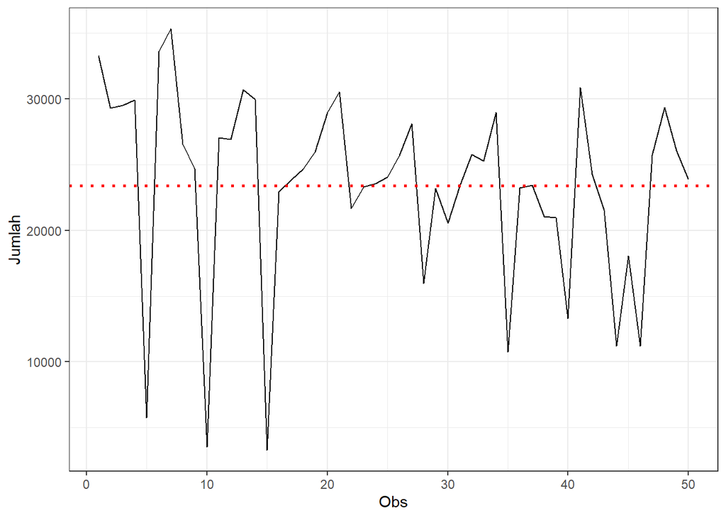

```r
plot_data51100 <- data51100 |> as_tsibble() |>
  ggplot(aes(x = index, y = value)) + geom_line() + theme_bw() +  geom_hline(yintercept = mean(data51100), linetype = "dotted", color = "red", size = 1) +   xlab("Obs") + ylab("Jumlah")
plot_data51100
```

```r
mean(data51100)
```

```
## [1] 23410.02
```

Plot deret waktu di atas menunjukkan bahwa data index tampak **stasioner dalam rataan**, yang ditandai dengan data yang menyebar di sekitar nilai tengah. Namun **tidak stasioner dalam ragam** karena lebar pitanya cenderung tidak sama.

## ACF Plot

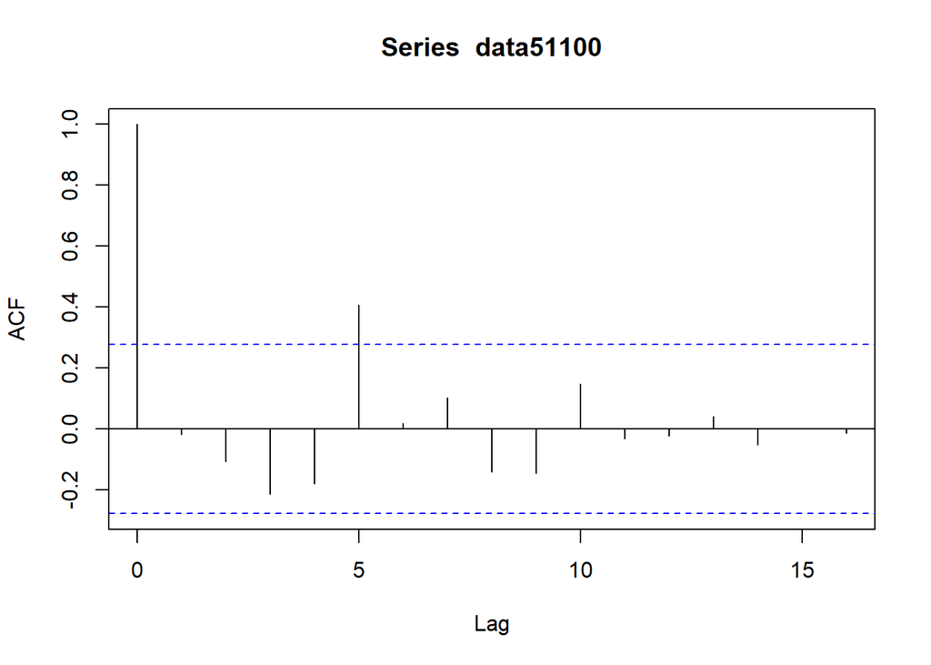

```r
acf(data51100)
```

Plot ACF data penuh menunjukkan data penuh cenderung *tails off*

## ADF Test

```r
adf.test(data51100)
```

```
##
##  Augmented Dickey-Fuller Test
##
## data:  data51100
## Dickey-Fuller = -7.0048, Lag order = 3, p-value = 0.01
## alternative hypothesis: stationary
```

$H_0$ : Data tidak stasioner dalam rataan

$H_1$ : Data stasioner dalam rataan

Berdasarkan *p-value* dari uji ADF pada data index 51-100(0.01), keputusan yang diambil adalah **tolak H0**, artinya data **stasioner dalam rataan**.

## Box-Cox Plot

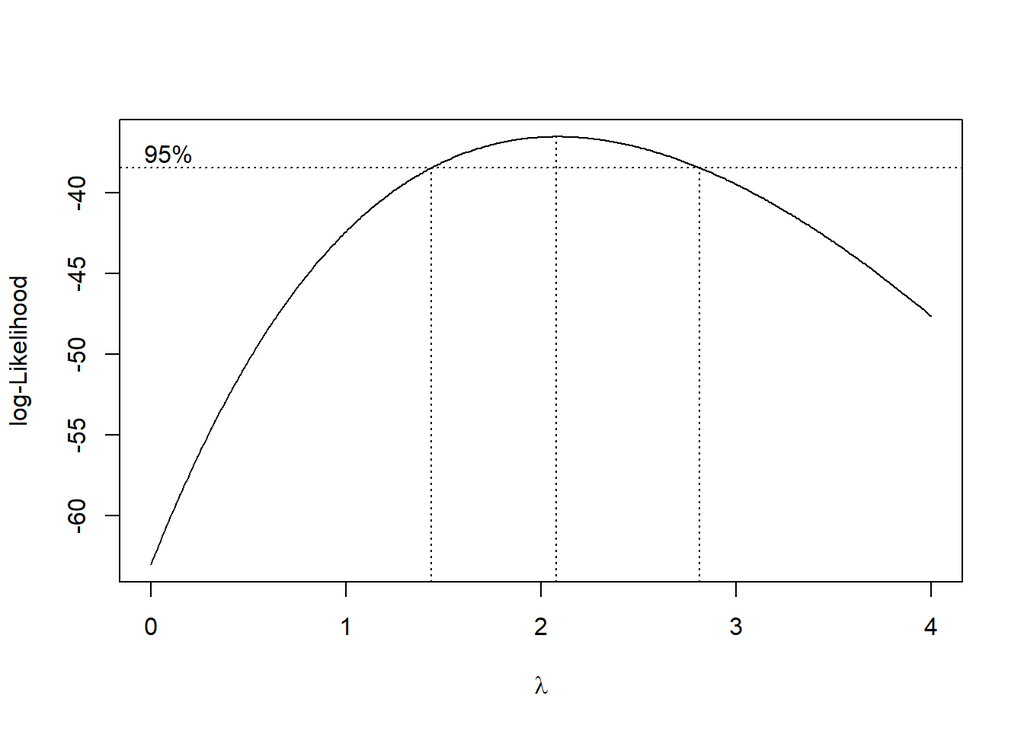

```r
bc51100 = boxcox(data51100~index51100, lambda = seq(0,4,by=0.01))
```

```r
#Nilai Rounded Lambda
lambda <- bc51100$x[which.max(bc51100$y)]
lambda
```

```
## [1] 2.08
```

```r
#SK
bc51100$x[bc51100$y > max(bc51100$y) - 1/2 * qchisq(.95,1)]
```

```
##   [1] 1.44 1.45 1.46 1.47 1.48 1.49 1.50 1.51 1.52 1.53 1.54 1.55 1.56 1.57 1.58
##  [16] 1.59 1.60 1.61 1.62 1.63 1.64 1.65 1.66 1.67 1.68 1.69 1.70 1.71 1.72 1.73
##  [31] 1.74 1.75 1.76 1.77 1.78 1.79 1.80 1.81 1.82 1.83 1.84 1.85 1.86 1.87 1.88
##  [46] 1.89 1.90 1.91 1.92 1.93 1.94 1.95 1.96 1.97 1.98 1.99 2.00 2.01 2.02 2.03
##  [61] 2.04 2.05 2.06 2.07 2.08 2.09 2.10 2.11 2.12 2.13 2.14 2.15 2.16 2.17 2.18
##  [76] 2.19 2.20 2.21 2.22 2.23 2.24 2.25 2.26 2.27 2.28 2.29 2.30 2.31 2.32 2.33
##  [91] 2.34 2.35 2.36 2.37 2.38 2.39 2.40 2.41 2.42 2.43 2.44 2.45 2.46 2.47 2.48
## [106] 2.49 2.50 2.51 2.52 2.53 2.54 2.55 2.56 2.57 2.58 2.59 2.60 2.61 2.62 2.63
## [121] 2.64 2.65 2.66 2.67 2.68 2.69 2.70 2.71 2.72 2.73 2.74 2.75 2.76 2.77 2.78
## [136] 2.79 2.80 2.81
```

Plot *Box-Cox* di atas menunjukkan nilai ($\lambda$) optimum sebesar **2.08** dan pada selang kepercayaan 95% nilai memiliki batas bawah **1.44** dan batas atas **2.81**. Selang tersebut **tidak** memuat nilai satu sehingga dapat dikatakan bahwa data index 51-100 **tidak stasioner dalam ragam**.

# Kesimpulan Panjang

Berdasarkan plot deret waktu, ketiga set data(data penuh(index 1-100), data index 1-50, dan data index 51-100)) cenderung stasioner dalam rataan namun tidak stasioner dalam ragam.  
Berdasarkan plot ACF, ketiga set data(data penuh(index 1-100), data index 1-50, dan data index 51-100)) cenderung *tails off*.  
Berdasarkan uji ADF, data penuh dan data index 1-50 memiliki *p-value* lebih dari taraf nyata 0.05(5%), artinya kedua set data tidak stasioner dalam rataan. Namun data index 51-100 memiliki *p-value* kurang dari taraf nyata 0.05(5%), artinya data index 51-100 stasioner dalam rataan.  
Berdasarkan plot *Box-Cox*, data penuh dan data index 1-50 memuat nilai satu pada selang batas bawah dan batas atas plot *Box-Cox*-nya. Artinya kedua set data ini stasioner dalam ragam. Namun data index 51-100 tidak memuat nilai satu pada selang plot *Box-Cox*-nya, artinya data index 51-100 tidak stasioner dalam ragam.

# Kesimpulan Pendek

Data penuh(1-100) *tails off* dari plot ACFnya, tidak stasioner dalam rataan, dan stasioner dalam ragam.  
Data index 1-50 *tails off* dari plot ACFnya, tidak stasioner dalam rataan, dan stasioner dalam ragam.  
Data index 51-100 *tails off* dari plot ACF, stasioner dalam rataan, dan tidak stasioner dalam ragam.